# Proficiency test: Corg

```r
library(tidyverse)
library(here)
library(ringtest) # remotes::install_github("bserrien/ringtest")
```

```r
load(here("data/ringtest-pilot.rda"))

# choose substrate of interest
data_ringtest_subst <- data_ringtest |>
  filter(subst == "Corg") |>
  unnest(cols = data)
```

## Data inspection

Are there any labs with more than 1 record? Yes (duplicates?)

```r
data_ringtest_subst |>
  filter(.by = lab_code, n() > 1) |>
  select(lab_code, meas_1, meas_2, meas_3, meas_mean)
```

```
# A tibble: 2 × 5
  lab_code meas_1 meas_2 meas_3 meas_mean
  <chr>     <dbl>  <dbl>  <dbl>     <dbl>
1 29         9.28   0.92  0.924      3.71
2 29        12.0   11.9  11.9       11.9
```

How should we deal with that? The email from 17/11/2026 mentions that the second row is the correct data.

```r
data_ringtest_subst_clean <- data_ringtest_subst |>
  filter(
    !(lab_code == "29" & round(meas_mean) == 4)
  )
```

Are all measurements in the same units? Yes.

```r
unique(data_ringtest_subst_clean$meas_unit)
```

```
[1] "g/kg"
```

Do all labs report in the same way? No

```r
data_ringtest_subst_clean |>
  summarise(.by = data_status, N = n())
```

```
# A tibble: 3 × 2
  data_status                                 N
  <ord>                                   <int>
1 at least 3 measured values submitted       20
2 less than 3 measured values submitted       8
3 value and unknown uncertainty submitted     3
```

A minimum reporting requirement for a lab should be:

- 3 replicate measurements
- measurement mean and uncertainty (SD)

The following labs don’t meet the criteria:

```r
data_ringtest_subst_clean <- data_ringtest_subst_clean |>
  mutate(
    check = case_when(
      !is.na(meas_1) & !is.na(meas_2) & !is.na(meas_3) ~ "3 measures",
      !is.na(meas_mean) & !is.na(meas_uncertain) ~ "mean +/- SD",
      TRUE ~ "not OK"
    )
  )

data_ringtest_subst_clean |>
  filter(check == "not OK") |>
  select(lab_code, meas_1, meas_2, meas_3, meas_4, meas_5,
         meas_mean, meas_uncertain)
```

```
# A tibble: 8 × 8
  lab_code meas_1 meas_2 meas_3 meas_4 meas_5 meas_mean meas_uncertain
  <chr>     <dbl>  <dbl>  <dbl>  <dbl>  <dbl>     <dbl>          <dbl>
1 24         9.4     9.8     NA     NA     NA      9.6              NA
2 11         8.27   NA       NA     NA     NA      8.27             NA
3 40         9.5    NA       NA     NA     NA      9.5              NA
4 21        11.3    NA       NA     NA     NA     11.3              NA
5 18        12.7    NA       NA     NA     NA     12.7              NA
6 13        10.4    NA       NA     NA     NA     10.4              NA
7 19        10.6    NA       NA     NA     NA     10.6              NA
8 42         4.1    NA       NA     NA     NA      4.1              NA
```

```r
data_ringtest_subst_clean <- data_ringtest_subst_clean |>
  filter(check != "not OK")
```

We remove the labs not meeting the above requirements (ISO clause 8.4.3.a).

In Figure 1 we display the data after the above cleaning steps.

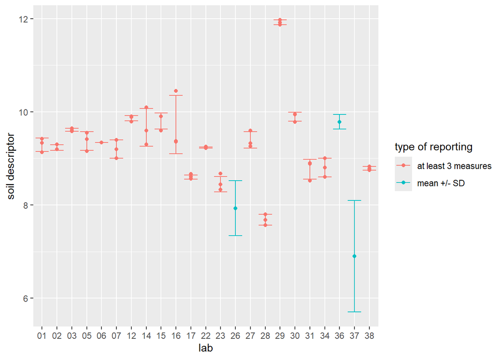

Figure 1: Raw data vizualisation. For labs reporting at least 3 measures we show the individual measurements and an error-bar extending to +/- 1 SD. For the labs reporting only the mean +/- SD, we show the mean and error-bar only.

```r
data_labs_ind <- data_ringtest_subst_clean |>
  filter(check == "3 measures") |>
  select(lab_code, contains("meas_")) |>
  select(-meas_unit) |>
  pivot_longer(
    paste0("meas_", 1:5), names_to = "replicate",
    values_to = "soil_descriptor"
  ) |>
  filter(!is.na(soil_descriptor)) |>
  mutate(
    .by = lab_code,
    meas_mean      = mean(soil_descriptor),
    meas_uncertain = sd(soil_descriptor)
  )

data_labs_aggr <- data_ringtest_subst_clean |>
  filter(check == "mean +/- SD") |>
  select(lab_code, meas_mean, meas_uncertain)

ggplot() +
  geom_point(
    data = data_labs_ind,
    aes(lab_code, soil_descriptor, color = "at least 3 measures")
  ) +
  geom_errorbar(
    data = data_labs_ind,
    aes(lab_code, color = "at least 3 measures",
        ymin = meas_mean - meas_uncertain,
        ymax = meas_mean + meas_uncertain)
  ) +
  geom_point(
    data = data_labs_aggr,
    aes(lab_code, meas_mean, color = "mean +/- SD")
  ) +
  geom_errorbar(
    data = data_labs_aggr,
    aes(lab_code, color = "mean +/- SD",
        ymin = meas_mean - meas_uncertain,
        ymax = meas_mean + meas_uncertain)
  ) +
  labs(x = "lab", y = "soil descriptor", color = "type of reporting")
```

## Proficiency test (ISO procedure)

How should we deal with this difference in reporting? We can’t use REML estimation, as this requires the raw data per replicate for all labs. We therefore use the classic approach based on aggregated cell-statistics.

We combine the cell-statistics from the two types of reporting. For labs reporting aggregated data, it is not reported on how many replicates this is based; we make the assumption of three replicates, but this needs verification.

```r
cell_stats <- rbind(
  # labs reporting individual data
  data_labs_ind |>
    rename(
      lab = lab_code,
      value = soil_descriptor
    ) |>
    mutate(level = 1) |>
    calc_cell_stats(),
  # labs reporting aggregated data
  data_labs_aggr |>
    rename(
      lab = lab_code,
      mean = meas_mean,
      sd = meas_uncertain
    ) |>
    mutate(
      level = 1,
      n = 3 # assumption: it is not reported on how many replicates it is based
    )
)

print(cell_stats)
```

```
   lab level n      mean         sd
1   06     1 3  9.340000 0.00000000
2   07     1 3  9.200000 0.20000000
3   02     1 3  9.233333 0.05773503
4   31     1 3  8.766667 0.21385353
5   30     1 3  9.893658 0.09541558
6   12     1 3  9.861873 0.05871312
7   03     1 3  9.610866 0.03263374
8   29     1 3 11.922581 0.05161290
9   15     1 3  9.800000 0.17320508
10  27     1 3  9.395989 0.17911888
11  34     1 3  8.800000 0.20000000
12  17     1 5  8.597212 0.04352706
13  28     1 3  7.683333 0.11503623
14  14     1 3  9.666667 0.40414519
15  01     1 3  9.295627 0.14534682
16  22     1 3  9.233333 0.01527525
17  38     1 3  8.784125 0.04082095
18  23     1 4  8.445579 0.16361441
19  16     1 3  9.727136 0.62379818
20  05     1 3  9.373333 0.19756855
21  26     1 3  7.930000 0.59000000
22  36     1 3  9.786000 0.15460000
23  37     1 3  6.900000 1.20000000
```

We calculate the Mandel $h$ and $k$ statistics to inspect for outlying means and variances, results are shown in Figure 2.

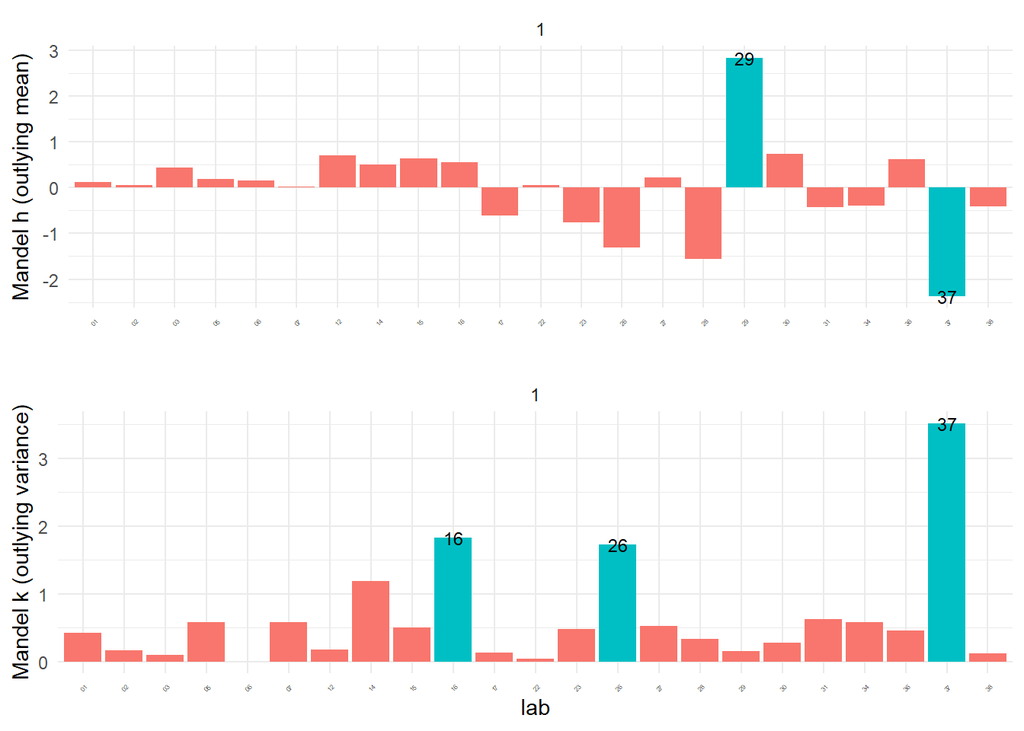

Figure 2: Mandel’s h & k statistics. Labs with outlying values at the 5% significance level are colored differently.

```r
calc_mandel_hk(cell_stats, alpha = 0.05) |>
  plot_mandel_hk()
```

Outlier removal should be an interactive process where the experts from the panel evaluate the data from a lab that is identified as outlier or straggler. Below we remove the outliers according to the ISO procedure using the Cochran (outlying variance) and Grubbs’ tests (outlying means). The function `outlier_removal_iso` automates the process without due investigation but prints the results so researchers can inspect the labs which have been removed. The ISO procedure mentions that only 2/9 of the data from a given level should be removed (8.3.6.2§2); which means for 23 labs only 5 can be removed; however, we previously removed already labs not meeting the reporting requirements, and I’m not sure if we have to count them as well (ISO manual is not clear on that point)?

The final cleaned statistics per lab are shown in Figure 3.

```r
cell_stats_final <- outlier_removal_iso(cell_stats, maxiter = NULL)
```

```
Iterative process to detect stragglers and outliers.
      Outliers are removed and stragglers retained.

 iteration 1:
 lab level n      cochran grubbs_single grubbs_double
  29     1 3         <NA> Straggler (*)          <NA>
  37     1 3 Outlier (**)          <NA>          <NA>

 iteration 2:
 lab level n      cochran grubbs_single grubbs_double
  29     1 3         <NA>  Outlier (**)          <NA>
  16     1 3 Outlier (**)          <NA>          <NA>

 iteration 3:
 lab level n      cochran grubbs_single grubbs_double
  26     1 3 Outlier (**)          <NA>          <NA>

 iteration 4:
 lab level n       cochran grubbs_single grubbs_double
  14     1 3 Straggler (*)          <NA>          <NA>

 Outlier detection ended after 4 iterations.
```

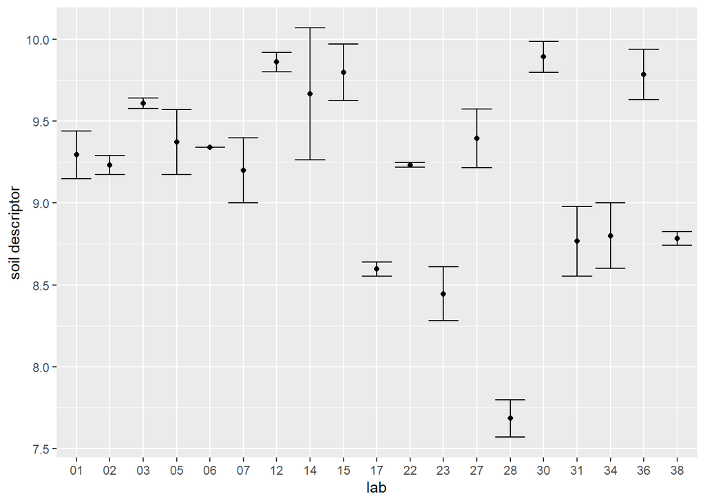

Figure 3: Aggregated statistics per lab after outlier removal.

```r
cell_stats_final |>
  ggplot(aes(lab, mean, ymin = mean - sd, ymax = mean + sd)) +
  geom_point() +
  geom_errorbar() +
  labs(x = "lab", y = "soil descriptor")
```

We now calculate the cleand mean and the variance components (as SD):

- `m_hat` = cleaned mean
- `s_r` = repeatability SD
- `s_L` = inter-laboratory SD
- `s_R` = reproducibility SD

$$\sigma_R^2 = \sigma_r^2 + \sigma_L^2$$

```r
res <- ringtest(cell_stats_final) |>
  mutate(
    # add coefficients of variation
    cv_r = s_r / m_hat,
    cv_L = s_L / m_hat,
    cv_R = s_R / m_hat
  )
res
```

```
   p    m_hat       s_r       s_L       s_R level       cv_r       cv_L
1 19 9.165713 0.1579189 0.5687534 0.5902701     1 0.01722931 0.06205228
       cv_R
1 0.0643998
```